# Excel Hell

# Excel Hell

# Learning Objectives

1. Learn about data types (columns)
2. Spreadsheets <> Data (Rows <> Observations)
3. Best practices for recording data
4. Common mistakes

# Outline

- Data Types
- Cardinal rules
- Common mistakes
- Unravelling Data
- Exporting to CSV
- Testing your spreadsheet

# Data types

> If in doubt, aim for **consistency in every column**. Never try to record more than one “type” of thing in a column.

# Integers & Decimals

- `...,-3,-2,0,1,2,3,...` versus `3.141529`
- Integers are any whole number
- Decimals include any number with a decimal point

# Strings

> A string is any sequence of characters.
- Literally anything you can type can be represented as a string.
- Default type in Excel
- Be careful `180mg` is not a number!

# Date/Time objects

- A number as far as the computer is concerned
- Often (but not always)
  - Dates are integers counted from 1 Jan 1970
  - Times are fractions of a day
- Other possibilities
  - milliseconds since 1960
  - Days since January 0 1900 (Excel!)

# Date gotcha’s

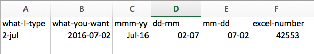

# Booleans

- `TRUE` or `FALSE` statements.
- `1` or `0` is a common shorthand

# Factors

- ‘Categorical’ (ordered or unordered)
- Integers with labels

# Nominal

- An **un**ordered (nominal) factor
- Named but not ordered

```
- apples
- oranges
- pears
```

- R stores this as `1,2,3` for convenience but not because `1<2<3`.

# Ordinal

- An ordered (ordinal) factor such as a Likert scale
- Ordered and named

```
- Strongly disagree
- Disagree
- Neither agree/disagree
- Agree
- Strongly agree
```

- R stores this as `1,2,3,4,5` for convenience and understands that `1<2<3<4<5`

# Exploring Datatypes in R Studio

# Your turn …

In R studio,

```
integers <- as.integer(c(1, 3, 15, 16))
decimals <- c(1.4, 3.5, 15.55, 16.4)
bools <- c(T, T, F, T)
dates <- as.Date(c("22/04/2016", "13/05/1997"), format = "%d/%m/%Y")
strings <- c("These are", "Strings")
factors <- as.factor(c("Apples", "Pears", "Lemons"))
factors <- as.factor(c("Good", "Better", "Best"), ordered=TRUE)
```

then use `str()` to see the data ‘structure’

# Cardinal rules

# Columns

> Put all your **variables in columns** - the thing you’re measuring, like ‘weight’, ‘temperature’ or ‘SBP’. Break things down into their most basic constituents, and keep units in your headers only.

# Rows

> Put each **observation in its own row**. Think very carefully about what constitutes your basic observation. Often it’s your patient, but it may not be as intuitive as you think.

# Headers

> Have a single ‘header’ row to label your columns

# Cells

> **Don’t combine multiple pieces of information in one cell**.

> **Leave the raw data raw** - don’t mess with it! That means no formulas anywhere in your spreadsheet!

# Sharing

> Export the cleaned data to a **text based format** like CSV. This ensures that anyone can use the data, and is the format required by most data repositories.

# Try to think like a computer

# The computer doesn’t care about formatting

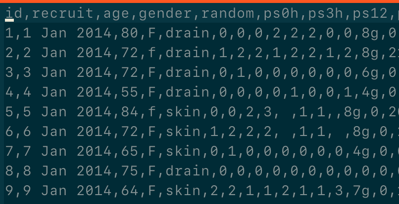

# We do …

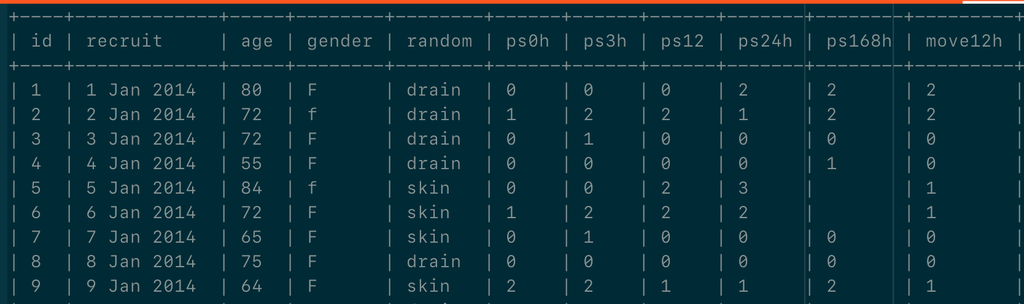

just add some white space and dividers

# And Excel …

And all excel does is present it to us in an easy to use format.

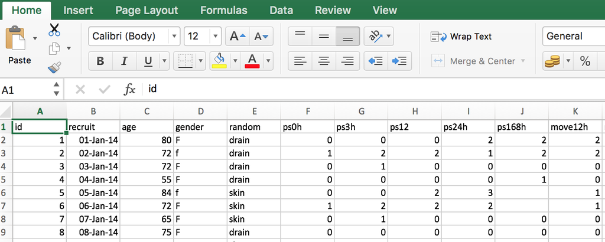

# But …

> But you always need to remember that you need to go back and forth between both formats.

> So merged cells, colours, comments will both be lost and confuse.

# Your turn …

# The data

- Raw data from an RCT on pain relief following mastectomy
- Download from [Figshare](https://figshare.com/s/165cad3ce6eadbf6b19a).

# Original (dirty)

[figure not shown]

# Your mission …

Identify and fix these common mistakes

# Common mistakes

- Multiple tables
- Multiple tabs
- Not filling in zeros
- Using bad null values
- Using formatting to convey information
- Using formatting to make the data sheet look pretty
- Placing comments or units in cells
- More than one piece of information in a cell
- Field name problems
- Special characters in data
- Inclusion of metadata in data table
- Date formatting

# Tips

- 3 sheets: readme, dictionary, data … then export,share the data sheet
- Data validation in Excel
- Learn to export to CSV